# Happiness Report of SAARC Country

R User Group Nepal

9/14/2018

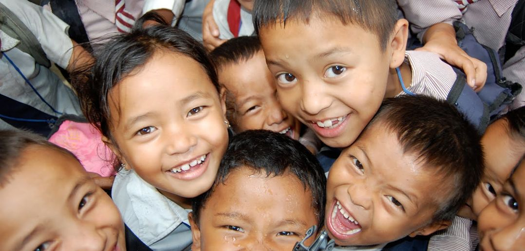

The [Happiness Report](http://worldhappiness.report/) is released by The Global Happiness Council (GHC). It takes factors like Life Expectancy, Freedom, GDP Per Capita, Trust On Government etc to calculate the Hapiness Score of country.This Report is about the Happiness and Related data of the Saarc Country.

[figure not shown]

### GDP Per Capita

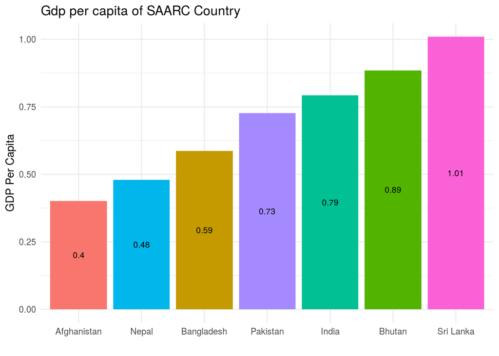

The above plot shows the Afghanistan is poorest country in South Asia and Sri lanka is richest Country by the mean of GDP Per capita. Nepal comes after the Afghanistan which means Nepal is second poor country in south Asia.

### Life Expectancy

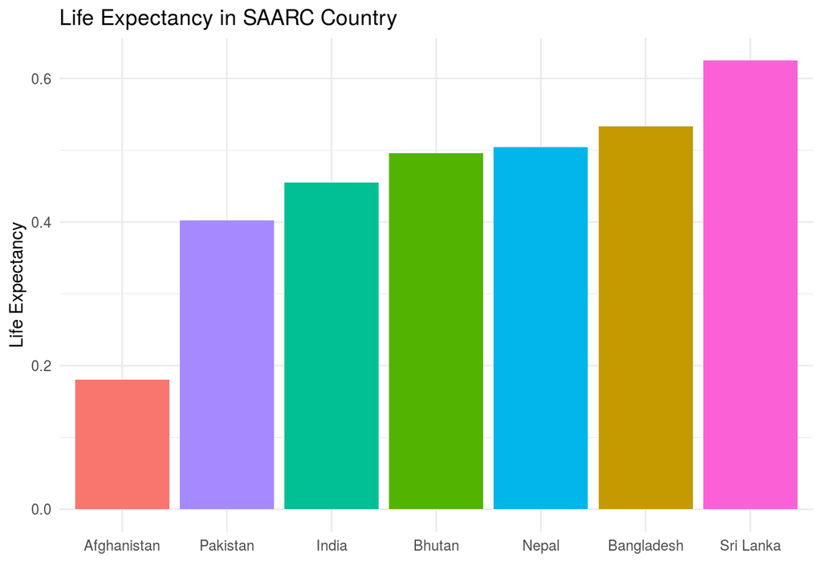

This Graphs shows Afghanistan has less Life Expectancy in SAARC. (Spoiler: It might be due to war going on Afghanistan and Pakistan.)

### Freedom

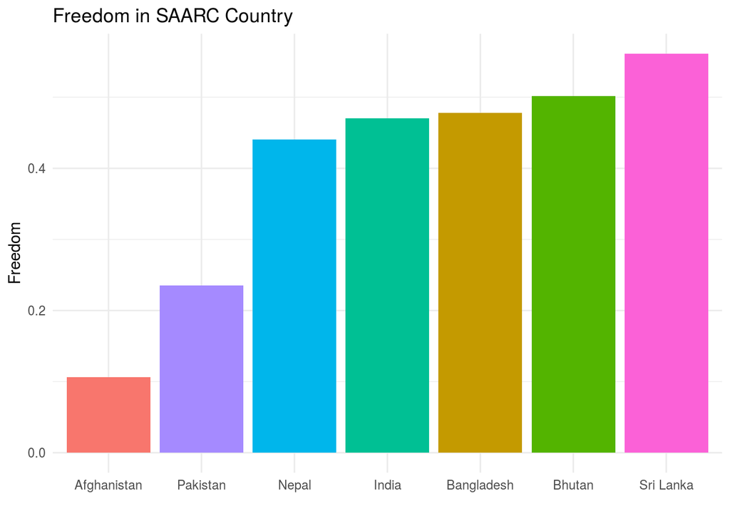

The people feel more freedom in sri lanka than rest of SAARC nation.

### Generosity

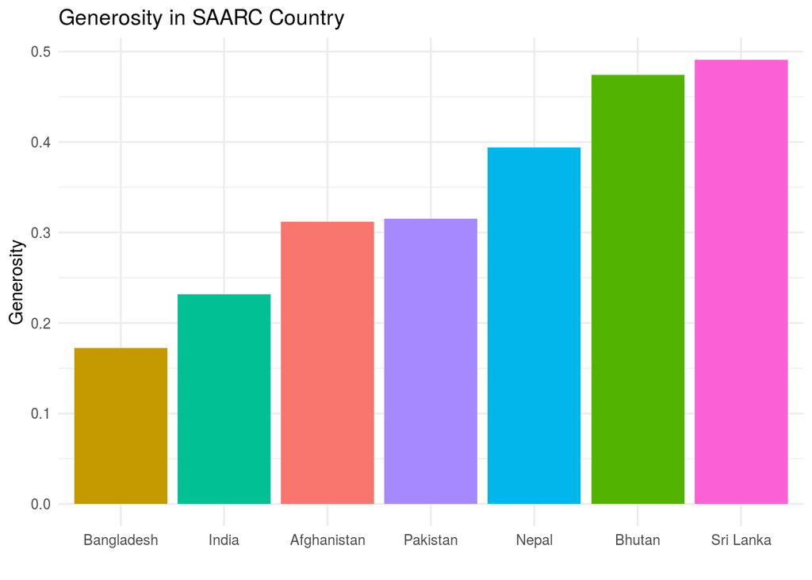

Sri lankan are most generous People in SAARC nations where as people of Bangladesh are not Generous.

### Happiness

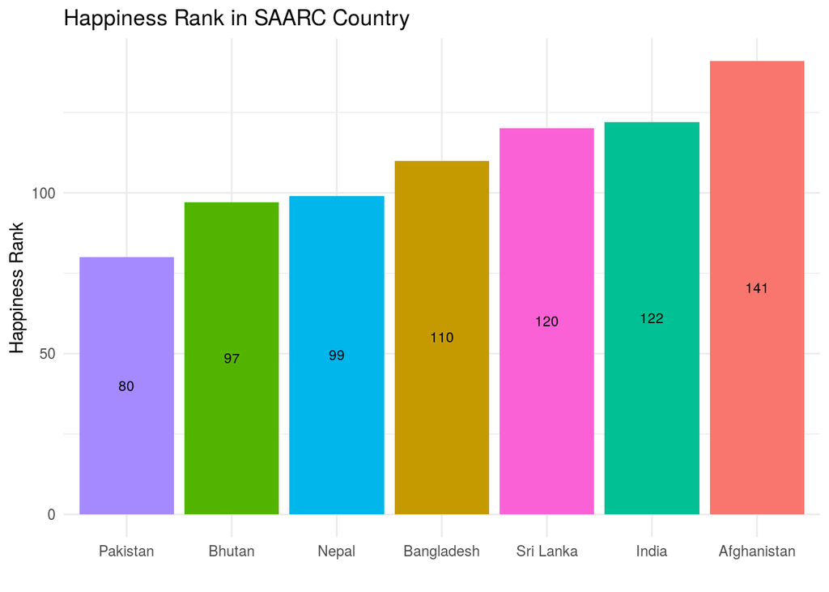

Above plot shows Pakistan is most happy country among SAARC countries.